# Coding Assignment 1

Team 4

Due: 2024-09-22 23:59

```r
# Put any packages you want here
library(gt)
library(gtsummary)
library(jtools)
library(tidyverse)
```

```r
library(plotly)
library(readxl)
library(dplyr)
library(corrplot)
```

A Florida health insurance company wants to predict annual claims for individual clients. The company pulls a random sample of 100 customers. The owner wishes to charge an actuarially fair premium to ensure a normal rate of return. The owner collects all of their current customer’s health care expenses from the last year and compares them with what is known about each customer’s plan.

The data on the 100 customers in the sample is as follows:

- Charges: Total medical expenses for a particular insurance plan (in dollars)
- Age: Age of the primary beneficiary
- BMI: Primary beneficiary’s body mass index (kg/m2)
- Female: Primary beneficiary’s birth sex (0 = Male, 1 = Female)
- Children: Number of children covered by health insurance plan (includes other dependents as well)
- Smoker: Indicator if primary beneficiary is a smoker (0 = non-smoker, 1 = smoker)
- Cities: Dummy variables for each city with the default being Sanford

Answer the following questions using complete sentences and attach all output, plots, etc. within this report.

**For this assignment, ignore the categorical variables (gender, smoker, cities)**

# Question 1

Perform univariate analyses on the quantitative variables (center, shape, spread). Include descriptive statistics, and histograms. Be sure to use terms discussed in class such as bimodal, skewed left, etc.

```r
mean(relevant_data$Charges)
```

```
## [1] 11884.11
```

```r
mean(relevant_data$Age)
```

```
## [1] 40.05
```

```r
mean(relevant_data$BMI)
```

```
## [1] 30.97005
```

```r
mean(relevant_data$Children)
```

```
## [1] 1.12
```

```r
median(relevant_data$Charges)
```

```
## [1] 8976.11
```

```r
median(relevant_data$Age)
```

```
## [1] 39.5
```

```r
median(relevant_data$BMI)
```

```
## [1] 30.875
```

```r
median(relevant_data$Children)
```

```
## [1] 1
```

```r
getModes <- function(x) {
  ux <- unique(x)
  tab <- tabulate(match(x, ux))
  ux[tab == max(tab)]
}

getModes(relevant_data$Charges)
```

[output not shown]

```r
getModes(relevant_data$Age)
```

```
## [1] 56
```

```r
getModes(relevant_data$BMI)
```

```
## [1] 30.875
```

```r
getModes(relevant_data$Children)
```

```
## [1] 0
```

```r
# Shape


# Spread
var(relevant_data$Charges)
```

```
## [1] 116280773
```

```r
var(relevant_data$Age)
```

```
## [1] 171.7247
```

```r
var(relevant_data$BMI)
```

```
## [1] 34.1152
```

```r
var(relevant_data$Children)
```

```
## [1] 1.318788
```

```r
sd(relevant_data$Charges)
```

```
## [1] 10783.36
```

```r
sd(relevant_data$Age)
```

```
## [1] 13.10438
```

```r
sd(relevant_data$BMI)
```

```
## [1] 5.840822
```

```r
sd(relevant_data$Children)
```

```
## [1] 1.148385
```

```r
IQR(relevant_data$Charges)
```

```
## [1] 8800.537
```

```r
IQR(relevant_data$Age)
```

```
## [1] 21
```

```r
IQR(relevant_data$BMI)
```

```
## [1] 7.6275
```

```r
IQR(relevant_data$Children)
```

```
## [1] 2
```

```r
range(relevant_data$Charges)
```

```
## [1]  1242.26 47269.85
```

```r
range(relevant_data$Age)
```

```
## [1] 18 64
```

```r
range(relevant_data$BMI)
```

```
## [1] 17.29 44.22
```

```r
range(relevant_data$Children)
```

```
## [1] 0 5
```

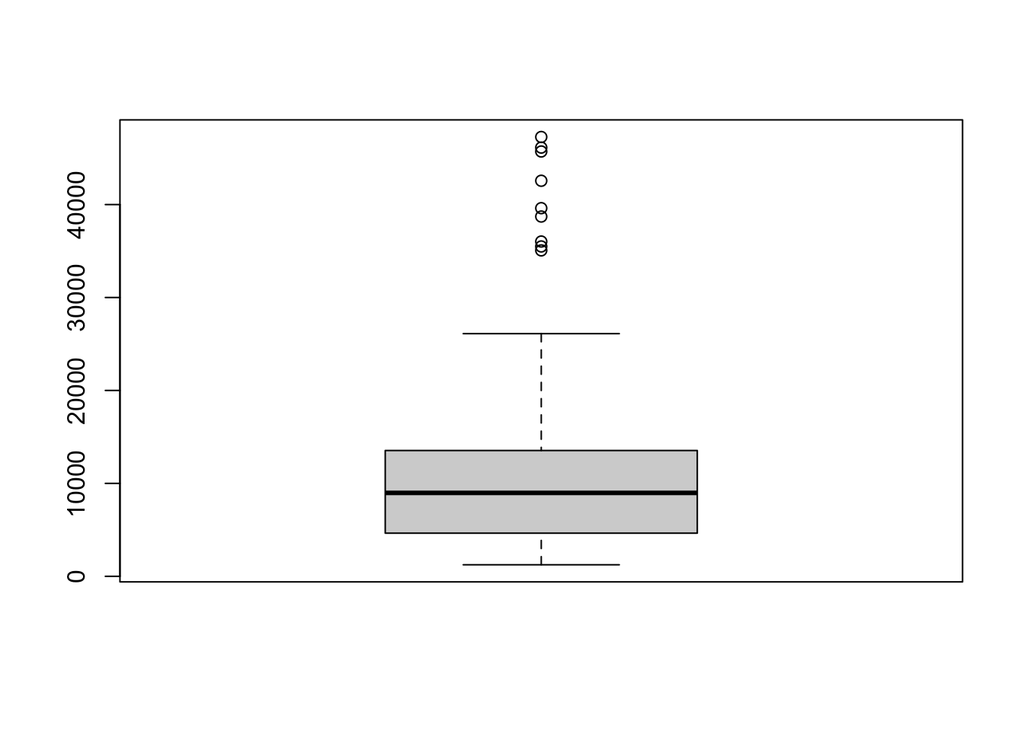

```r
# Visualizing Spread
boxplot(relevant_data$Charges)
```

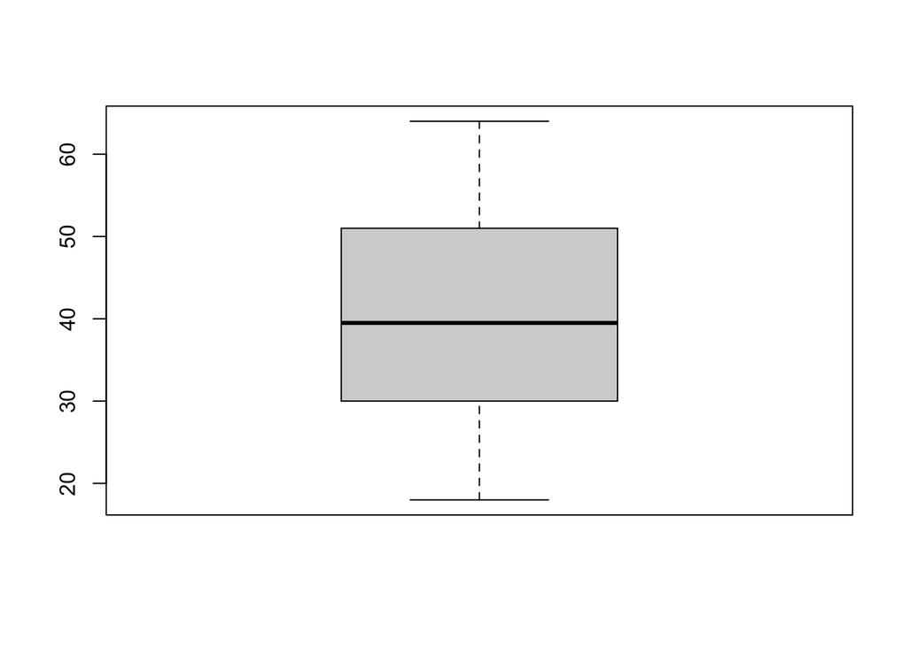

```r
boxplot(relevant_data$Age)
```

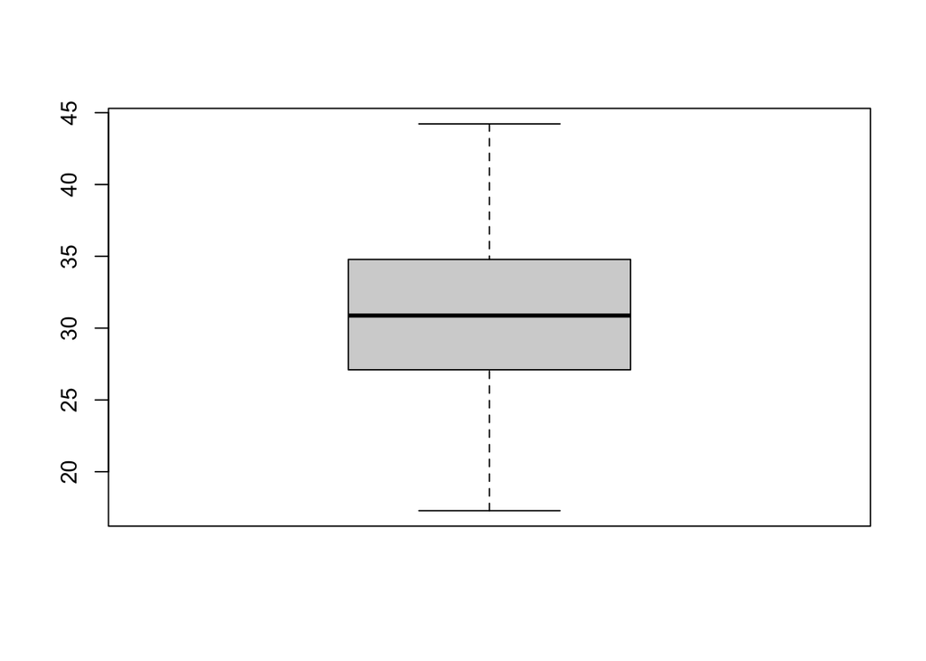

```r
boxplot(relevant_data$BMI)
```

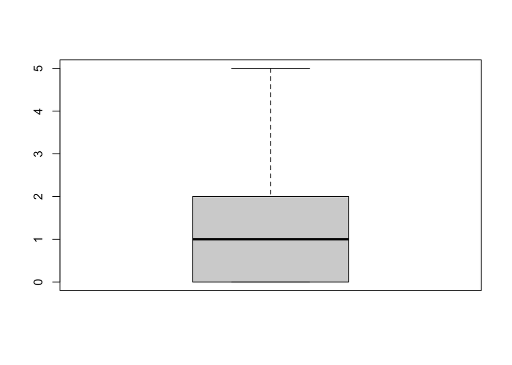

```r
boxplot(relevant_data$Children)
```

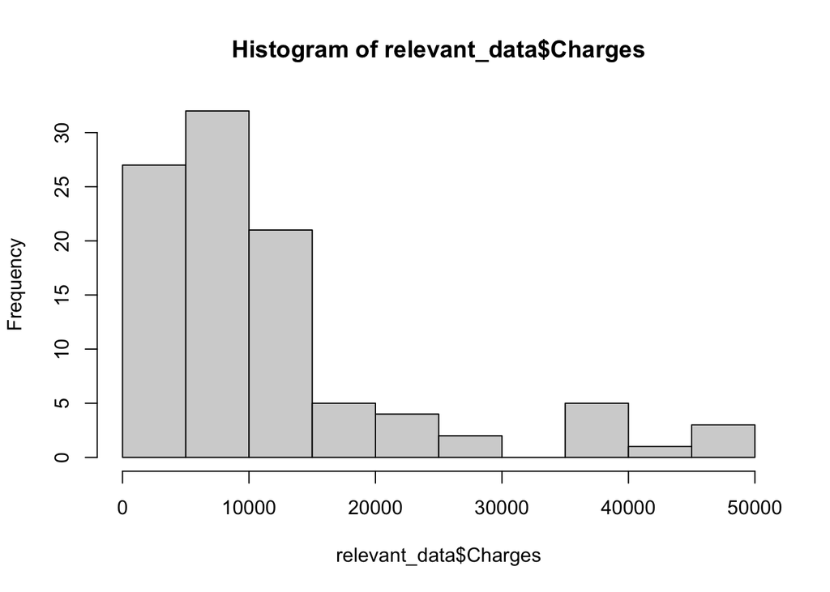

```r
hist(relevant_data$Charges, breaks = "fd")
```

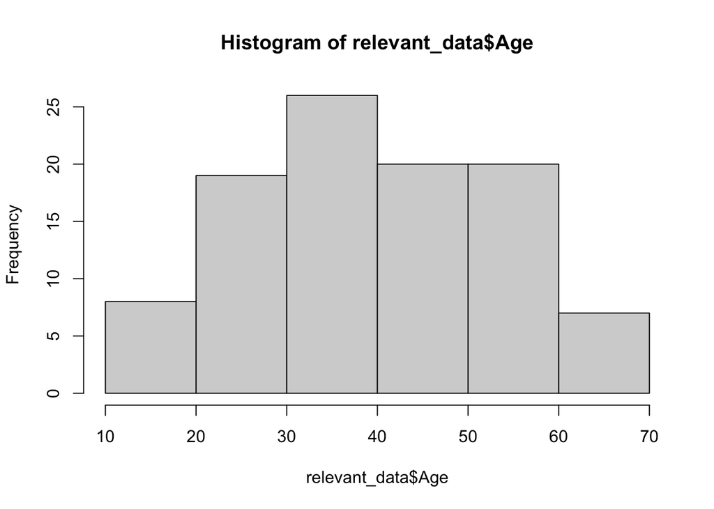

```r
hist(relevant_data$Age, breaks = "fd")
```

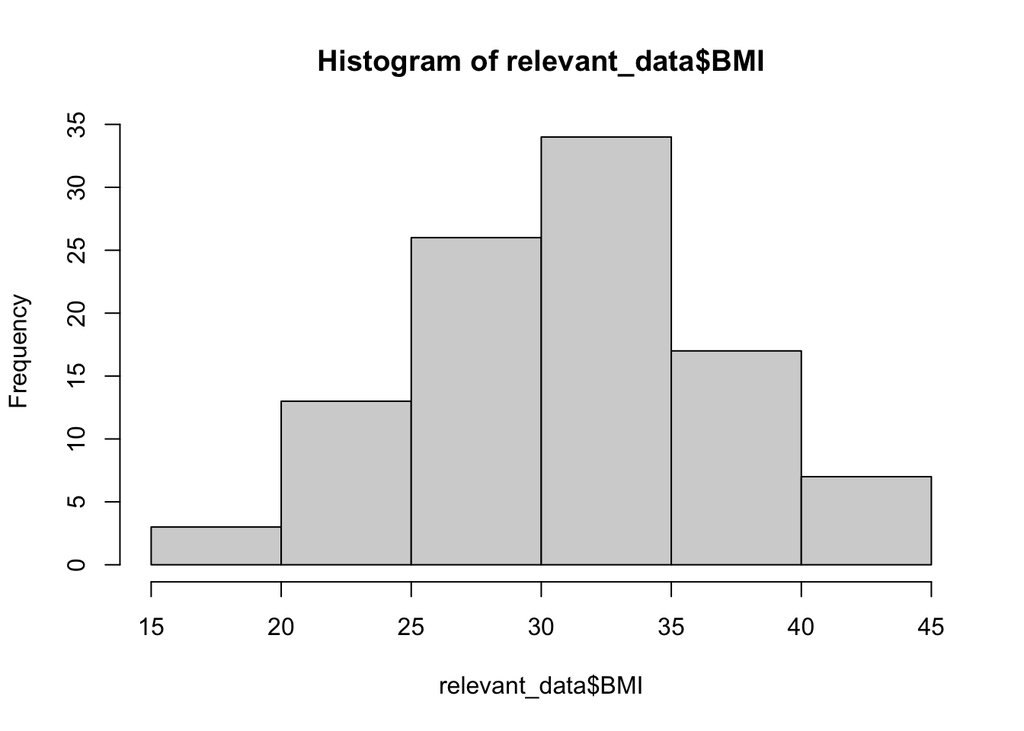

```r
hist(relevant_data$BMI, breaks = "fd")
```

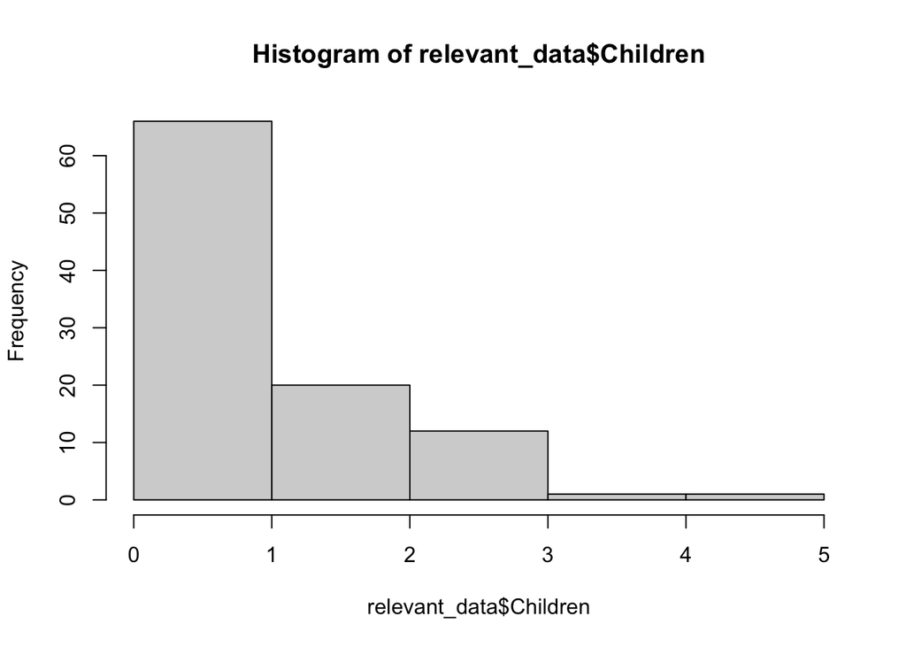

```r
hist(relevant_data$Children, breaks = "fd")
```

# Question 2

Perform bivariate analyses on the quantitative variables (direction, strength and form). Describe the linear association between all variables.

```r
cor(relevant_data$Charges, relevant_data$Age)
```

```
## [1] 0.3517258
```

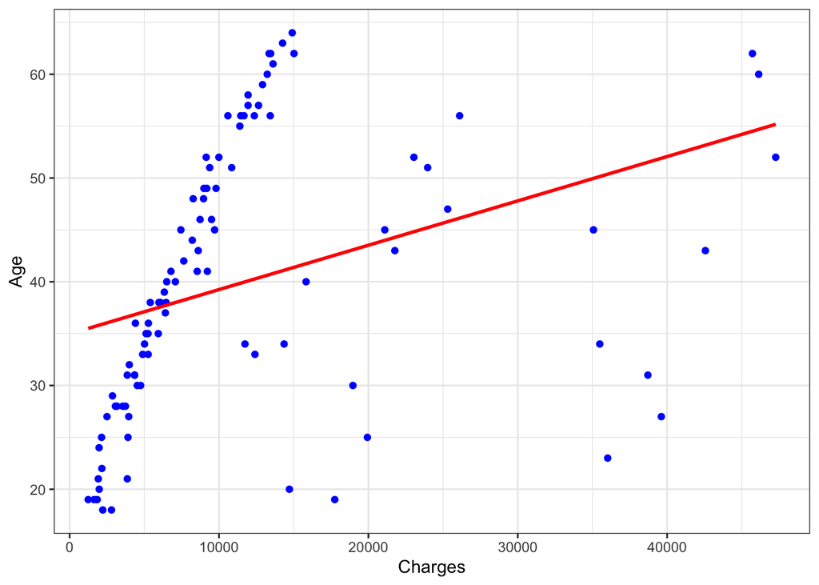

```r
ggplot(relevant_data, aes(Charges, Age))+
geom_point(color="blue")+
geom_smooth(,method="lm", se=FALSE, color="red")+
  theme_bw()
```

```r
cor(relevant_data$Charges, relevant_data$BMI)
```

```
## [1] 0.1365285
```

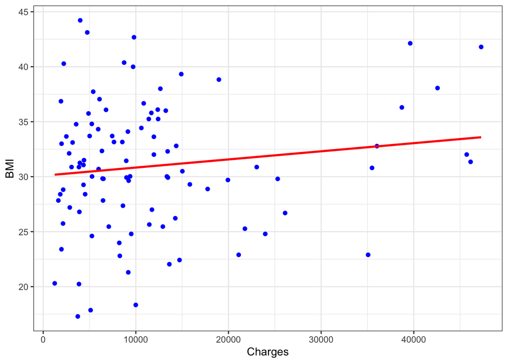

```r
ggplot(relevant_data, aes(Charges, BMI))+
geom_point(color="blue")+
geom_smooth(,method="lm", se=FALSE, color="red")+
  theme_bw()
```

```r
cor(relevant_data$Charges, relevant_data$Children)
```

```
## [1] 0.1429509
```

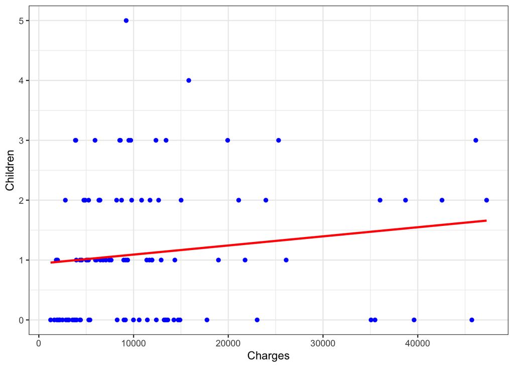

```r
ggplot(relevant_data, aes(Charges, Children))+
geom_point(color="blue")+
geom_smooth(,method="lm", se=FALSE, color="red")+
  theme_bw()
```

```r
cor(relevant_data$Age, relevant_data$BMI)
```

```
## [1] 0.05525174
```

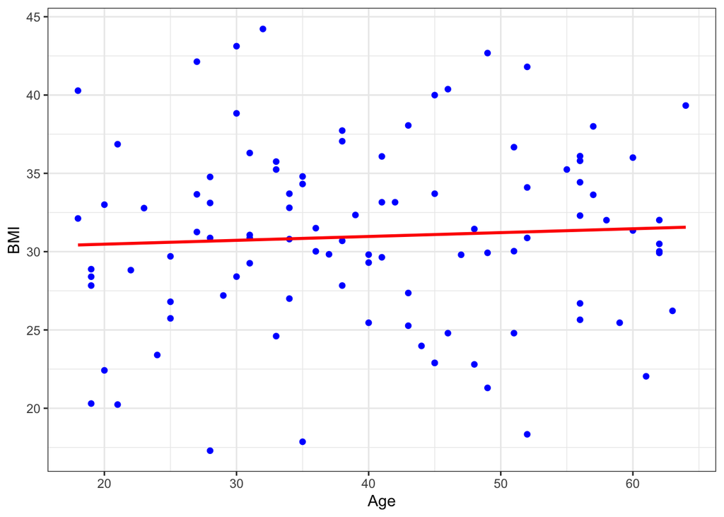

```r
ggplot(relevant_data, aes(Age, BMI))+
geom_point(color="blue")+
geom_smooth(,method="lm", se=FALSE, color="red")+
  theme_bw()
```

```r
cor(relevant_data$Age, relevant_data$Children)
```

```
## [1] 0.08215657
```

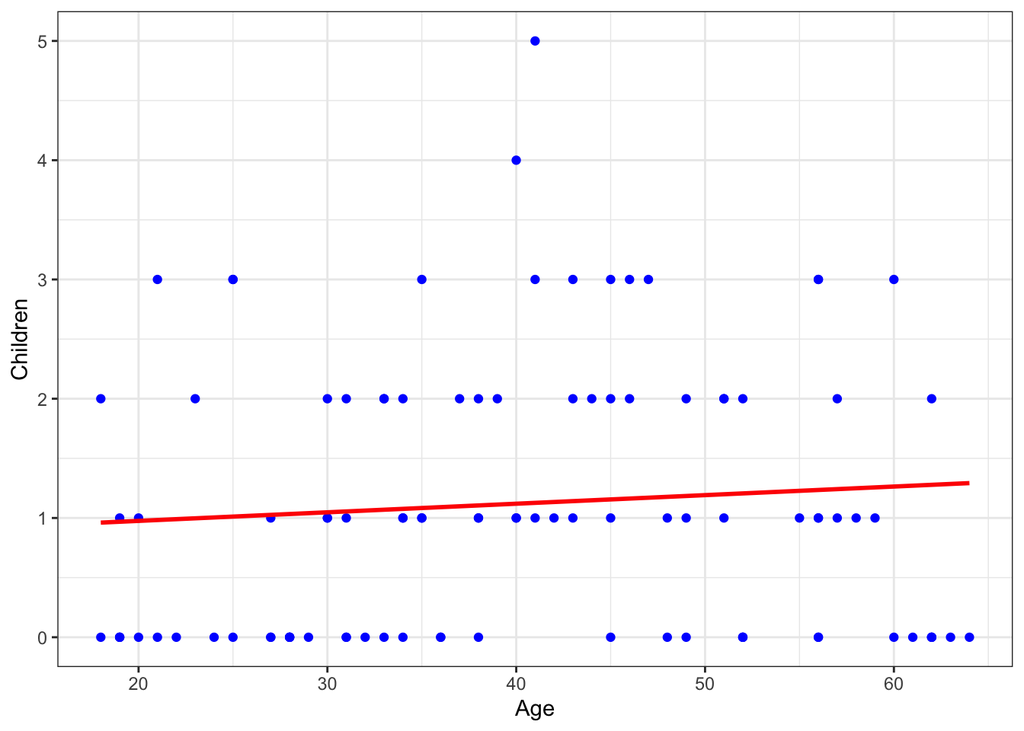

```r
ggplot(relevant_data, aes(Age, Children))+
geom_point(color="blue")+
geom_smooth(,method="lm", se=FALSE, color="red")+
  theme_bw()
```

```r
cor(relevant_data$BMI, relevant_data$Children)
```

```
## [1] 0.07301387
```

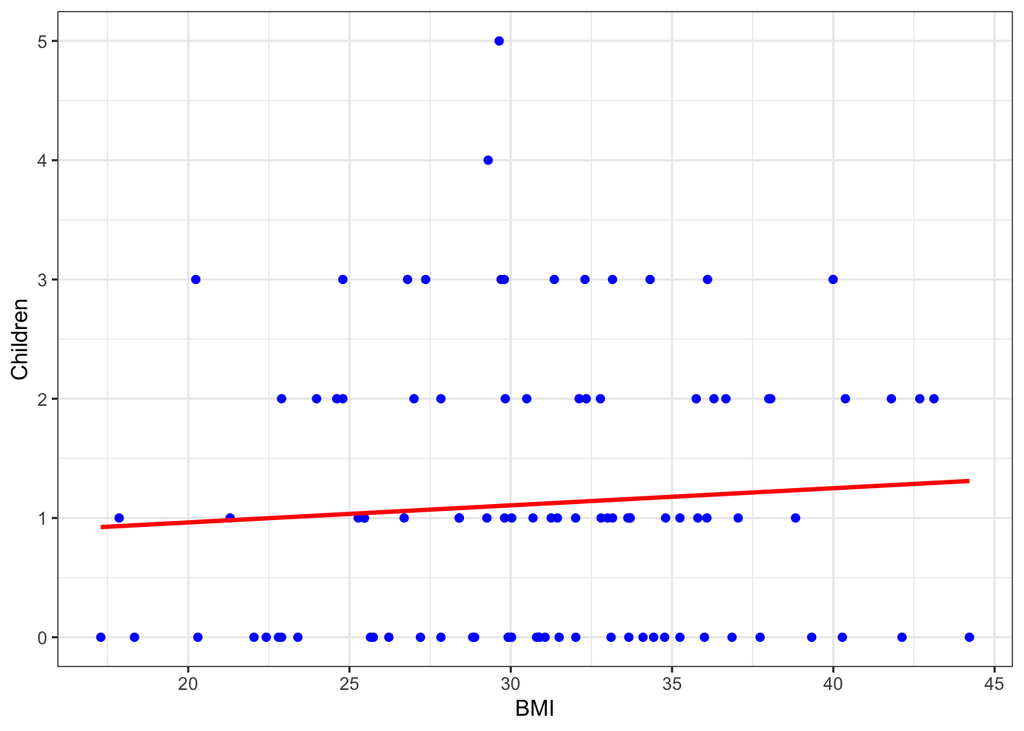

```r
ggplot(relevant_data, aes(BMI, Children))+
geom_point(color="blue")+
geom_smooth(,method="lm", se=FALSE, color="red")+
  theme_bw()
```

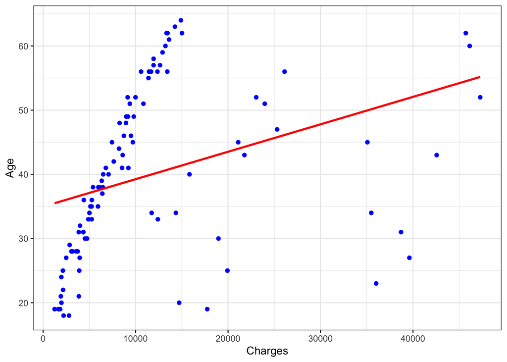

```r
ggplot(relevant_data, aes(Charges, Age))+
geom_point(color="blue")+
geom_smooth(,method="lm", se=FALSE, color="red")+
  theme_bw()
```

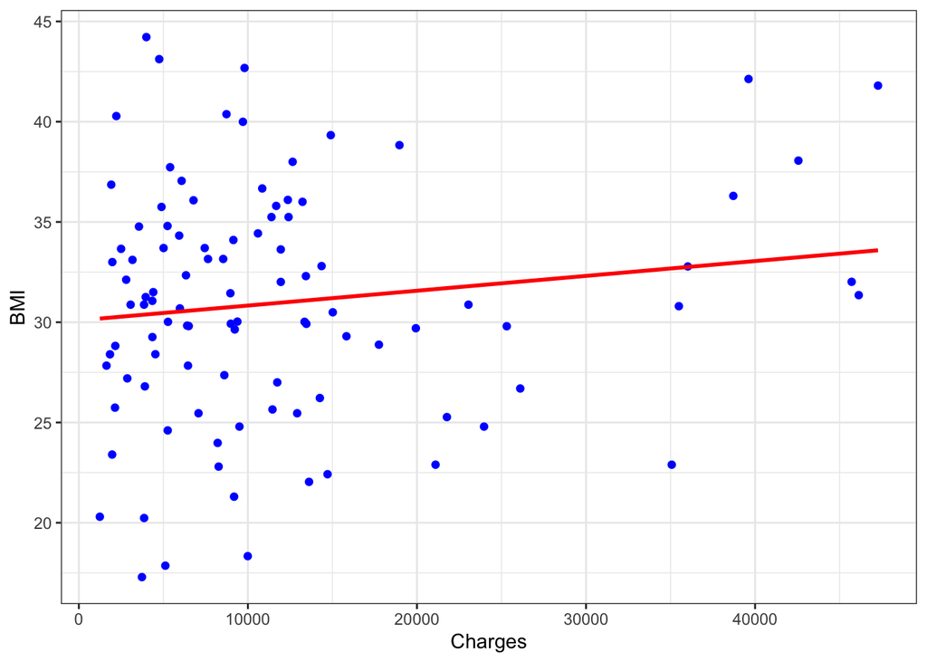

```r
ggplot(relevant_data, aes(Charges, BMI))+
geom_point(color="blue")+
geom_smooth(,method="lm", se=FALSE, color="red")+
  theme_bw()
```

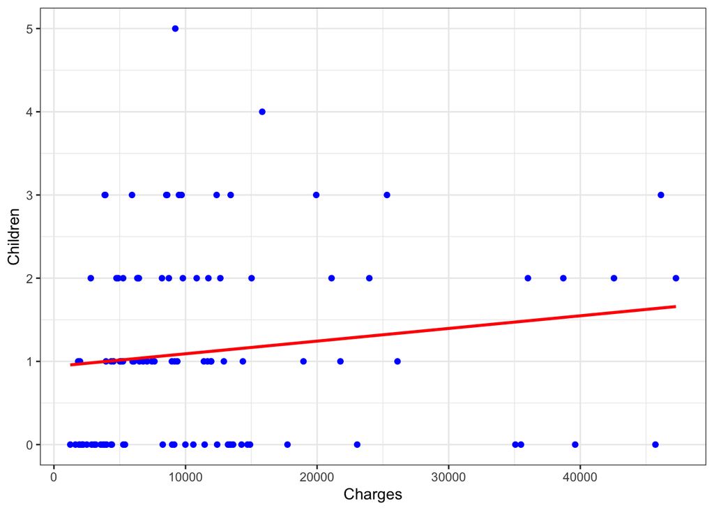

```r
ggplot(relevant_data, aes(Charges, Children))+
geom_point(color="blue")+
geom_smooth(,method="lm", se=FALSE, color="red")+
  theme_bw()
```

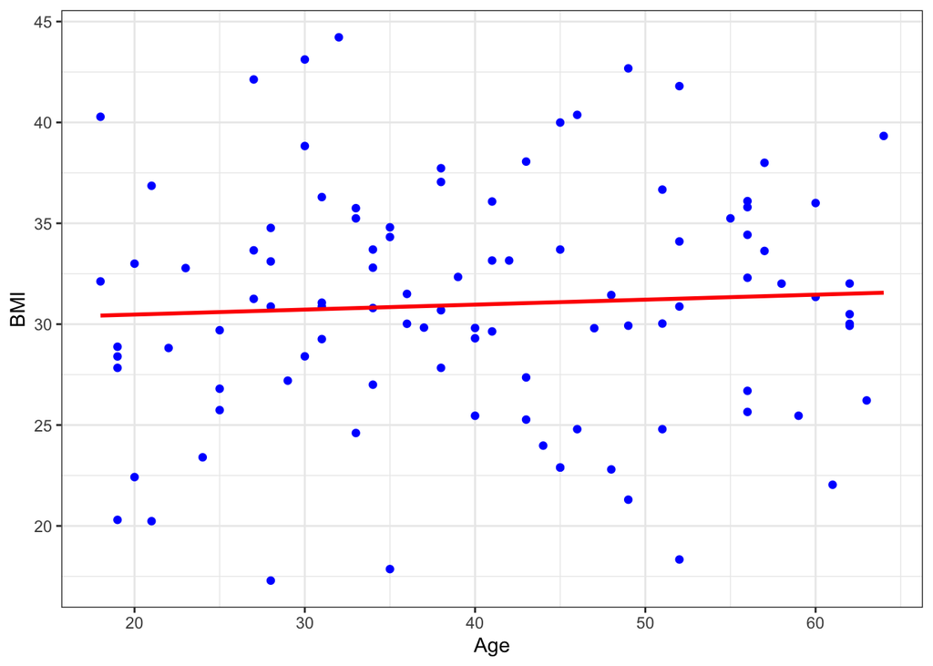

```r
ggplot(relevant_data, aes(Age, BMI))+
geom_point(color="blue")+
geom_smooth(,method="lm", se=FALSE, color="red")+
  theme_bw()
```

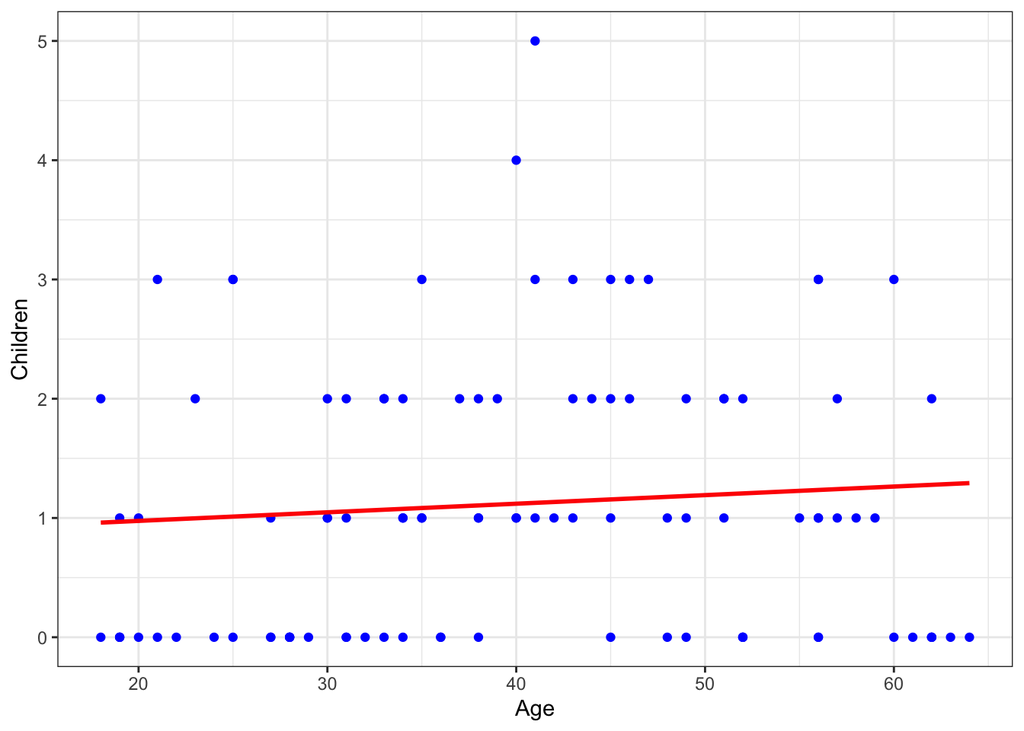

```r
ggplot(relevant_data, aes(Age, Children))+
geom_point(color="blue")+
geom_smooth(,method="lm", se=FALSE, color="red")+
  theme_bw()
```

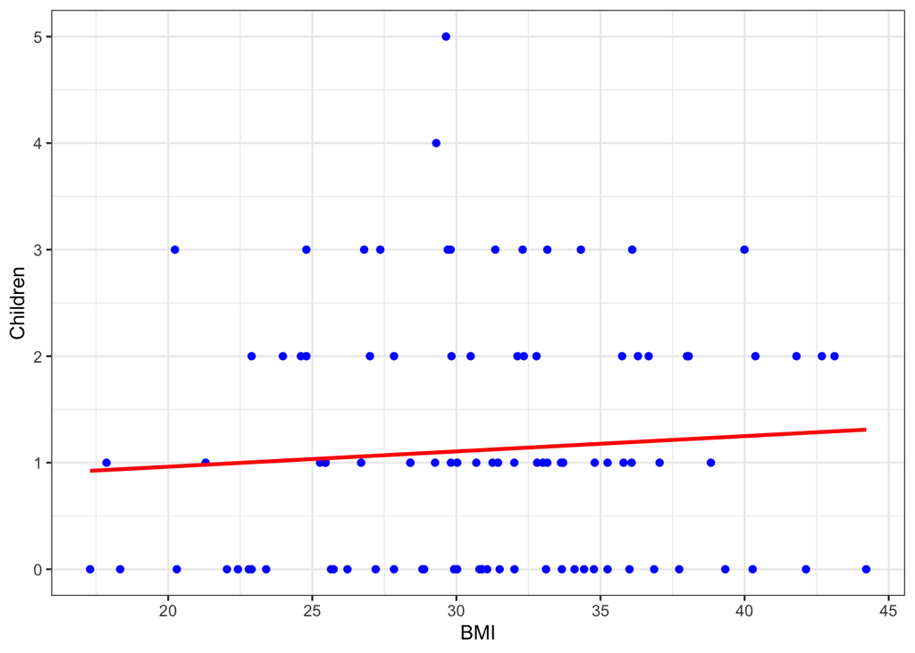

```r
ggplot(relevant_data, aes(BMI, Children))+
geom_point(color="blue")+
geom_smooth(,method="lm", se=FALSE, color="red")+
  theme_bw()
```

- Charges and Age have a moderate positive correlation. 0.3517 shows as age increases, the charges tend to increase as well, but the relationship is not extremely strong.
- Charges and BMI have a weak positive correlation. 0.1365 shows as BMI increases, the charges increase narrowly, but the relationship has little strength.
- Charges and Children have a weak positive correlation. 0.1430 shows as the number of children increases, the charges increase narrowly, but the relationship has little strength.
- Age and BMI have a weak, almost non existent, positive correlation. 0.0553 is so weak that it’s hard to distinguish the effects of one increasing or decreasing.
- Age and Children have a weak positive correlation. 0.0822 shows that there is a slight tendency for older people to have more children.
- BMI and Children have a weak, almost non existent, positive correlation. 0.0730 is so weak that it’s hard to distinguish the effects of one increasing or decreasing.

# Question 3

Generate a regression equation in the following form:

$$Charges =
-6639.02+277.17*Age+203.24*BMI+1006.99*Children$$

```r
model <- lm(Charges ~ Age + BMI + Children, data = relevant_data)
summary(model)
```

```
##
## Call:
## lm(formula = Charges ~ Age + BMI + Children, data = relevant_data)
##
## Residuals:
##    Min     1Q Median     3Q    Max
##  -7830  -5263  -4180  -1415  30204
##
## Coefficients:
##             Estimate Std. Error t value Pr(>|t|)
## (Intercept) -6639.02    6168.22  -1.076 0.284478
## Age           277.17      77.84   3.561 0.000577 ***
## BMI           203.24     174.52   1.165 0.247071
## Children     1006.99     889.28   1.132 0.260304
## ---
## Signif. codes:  0 '***' 0.001 '**' 0.01 '*' 0.05 '.' 0.1 ' ' 1
##
## Residual standard error: 10100 on 96 degrees of freedom
## Multiple R-squared:  0.1488, Adjusted R-squared:  0.1222
## F-statistic: 5.595 on 3 and 96 DF,  p-value: 0.001403
```

also write out the regression cleanly in this document.

# Question 4

An eager insurance representative comes back with a potential client. The client is 40, their BMI is 30, and they have one dependent. Using the regression equation above, predict the amount of medical expenses associated with this policy. (Provide a 95% confidence interval as well)

```r
newPrediction <- data.frame(Age = 40,
                            BMI = 30,
                            Children = 1)
predict(model, newdata = newPrediction, interval = "confidence", level = 0.95)
```

```
##        fit      lwr     upr
## 1 11552.25 9510.398 13594.1
```

- The regression equation predicts that the amount of medical expenses associated with the policy will be 11,552 dollars with the lower end being 9,510 dollars and upper end being 13,594 dollars using a confidence interval of 95%. Depending on the independent variables of age, BMI, and children the medical expense could vary.